# Understanding the Sampling Distribution of the Mean

Tanishka Joshi

2026-06-10

## What is a Sampling Distribution?

When you collect data, you’re usually working with a **sample** — a subset of a larger **population**. If you calculated the mean of that sample, you’d get one number. But what if you took a *different* sample? You’d likely get a slightly different mean.

The **sampling distribution of the mean** is the distribution of all those possible sample means. It tells us:

- What values the sample mean tends to take
- How much the sample mean varies from sample to sample
- How reliable our estimate of the true population mean is

The **Central Limit Theorem (CLT)** is one of the most important results in statistics. It states:

> *No matter what shape the original population has, the sampling distribution of the mean will approach a **normal distribution** as the sample size gets large.*

Let’s see this in action.

## Step 1: Create a Non-Normal Population

To make this interesting, we’ll use a **right-skewed population** (like income, wait times, or reaction times) — something clearly *not* normal. This makes the CLT’s magic more dramatic.

```r
set.seed(42)

# Create a large skewed population using an exponential distribution
# Think of this as representing something like "time until an event occurs"
population_size <- 100000
population <- rexp(n = population_size, rate = 0.2)

# True population parameters
pop_mean <- mean(population)
pop_sd   <- sd(population)

cat("Population size:", population_size, "\n")
```

```
Population size: 1e+05
```

```r
cat("True population mean:", round(pop_mean, 3), "\n")
```

```
True population mean: 4.991
```

```r
cat("True population SD:  ", round(pop_sd, 3), "\n")
```

```
True population SD:   5.003
```

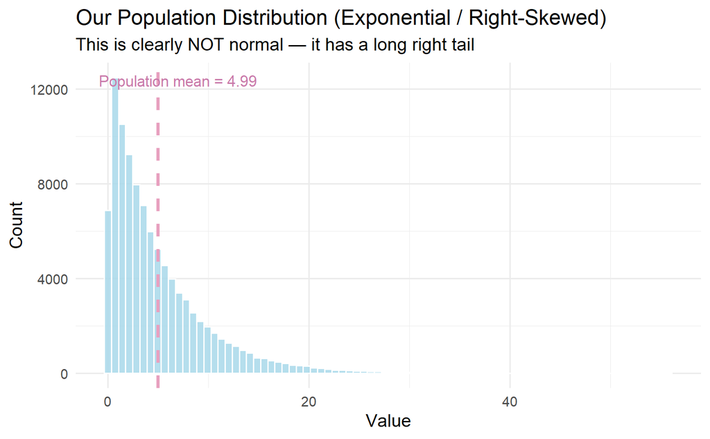

```r
ggplot(data.frame(x = population), aes(x = x)) +
  geom_histogram(bins = 80, fill = "#a8d8ea", color = "white", alpha = 0.85) +
  geom_vline(xintercept = pop_mean, color = "#e8a0bf", linewidth = 1.2, linetype = "dashed") +
  annotate("text", x = pop_mean + 2, y = Inf, vjust = 2,
           label = paste("Population mean =", round(pop_mean, 2)),
           color = "#c97aaa", size = 4) +
  labs(
    title = "Our Population Distribution (Exponential / Right-Skewed)",
    subtitle = "This is clearly NOT normal — it has a long right tail",
    x = "Value",
    y = "Count"
  ) +
  theme_minimal(base_size = 13)
```

**What you’re seeing:** The population is strongly right-skewed. Most values are small, but a few are very large. The red dashed line is the true mean of the whole population.

## Step 2: The Sampling Process

For each of three sample sizes (small, medium, large), we will:

1. Draw 1,000 random samples from the population
2. Calculate the mean of each sample
3. Collect all 1,000 sample means into a **sampling distribution**

```r
# A function that draws `n_samples` samples of size `sample_size`
# and returns all the sample means
get_sample_means <- function(population, sample_size, n_samples = 1000) {
  replicate(n_samples, mean(sample(population, size = sample_size, replace = FALSE)))
}

# Define our three sample sizes
small_n  <- 5
medium_n <- 30
large_n  <- 100

# Draw 1000 samples at each size
set.seed(123)
means_small  <- get_sample_means(population, small_n)
means_medium <- get_sample_means(population, medium_n)
means_large  <- get_sample_means(population, large_n)

cat("Done! Collected 1000 sample means for each sample size.\n")
```

```
Done! Collected 1000 sample means for each sample size.
```

## Step 3: Visualize the Sampling Distributions

Now let’s plot all three sampling distributions side by side and compare them to the shape of the original population.

```r
# Combine into a single tidy data frame for ggplot
sampling_data <- bind_rows(
  data.frame(mean_val = means_small,  sample_size = paste0("Small (n = ", small_n, ")")),
  data.frame(mean_val = means_medium, sample_size = paste0("Medium (n = ", medium_n, ")")),
  data.frame(mean_val = means_large,  sample_size = paste0("Large (n = ", large_n, ")"))
)

# Keep factor order: Small → Medium → Large
sampling_data$sample_size <- factor(
  sampling_data$sample_size,
  levels = c(
    paste0("Small (n = ", small_n, ")"),
    paste0("Medium (n = ", medium_n, ")"),
    paste0("Large (n = ", large_n, ")")
  )
)

# Compute summary stats per group for annotation
summary_stats <- sampling_data %>%
  group_by(sample_size) %>%
  summarise(
    mean_of_means = mean(mean_val),
    sd_of_means   = sd(mean_val),
    .groups = "drop"
  )

print(summary_stats)
```

```
# A tibble: 3 × 3
  sample_size     mean_of_means sd_of_means
  <fct>                   <dbl>       <dbl>
1 Small (n = 5)            5.04       2.27
2 Medium (n = 30)          5.00       0.941
3 Large (n = 100)          5.00       0.505
```

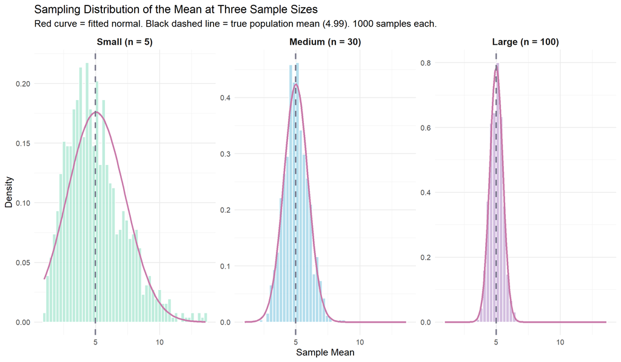

```r
ggplot(sampling_data, aes(x = mean_val, fill = sample_size)) +
  geom_histogram(aes(y = after_stat(density)), bins = 50,
                 color = "white", alpha = 0.85) +

  # Overlay a normal curve using each group's observed mean and SD
  stat_function(
    data = filter(sampling_data, sample_size == paste0("Small (n = ", small_n, ")")),
    fun = dnorm,
    args = list(
      mean = filter(summary_stats, grepl("Small", sample_size))$mean_of_means,
      sd   = filter(summary_stats, grepl("Small", sample_size))$sd_of_means
    ),
    color = "#c97aaa", linewidth = 1.1
  ) +
  stat_function(
    data = filter(sampling_data, sample_size == paste0("Medium (n = ", medium_n, ")")),
    fun = dnorm,
    args = list(
      mean = filter(summary_stats, grepl("Medium", sample_size))$mean_of_means,
      sd   = filter(summary_stats, grepl("Medium", sample_size))$sd_of_means
    ),
    color = "#c97aaa", linewidth = 1.1
  ) +
  stat_function(
    data = filter(sampling_data, sample_size == paste0("Large (n = ", large_n, ")")),
    fun = dnorm,
    args = list(
      mean = filter(summary_stats, grepl("Large", sample_size))$mean_of_means,
      sd   = filter(summary_stats, grepl("Large", sample_size))$sd_of_means
    ),
    color = "#c97aaa", linewidth = 1.1
  ) +

  # True population mean line
  geom_vline(xintercept = pop_mean, color = "#7a7a8c", linewidth = 1,
             linetype = "dashed") +

  facet_wrap(~ sample_size, scales = "free_y", ncol = 3) +
  scale_fill_manual(values = c("#b5ead7", "#a8d8ea", "#cdb4db")) +
  labs(
    title = "Sampling Distribution of the Mean at Three Sample Sizes",
    subtitle = paste0(
      "Red curve = fitted normal. Black dashed line = true population mean (",
      round(pop_mean, 2), "). 1000 samples each."
    ),
    x = "Sample Mean",
    y = "Density",
    fill = "Sample Size"
  ) +
  theme_minimal(base_size = 13) +
  theme(legend.position = "none", strip.text = element_text(face = "bold", size = 13))
```

## Step 4: What’s Actually Happening?

### Small Sample Size (n = 5)

```r
s <- filter(summary_stats, grepl("Small", sample_size))
cat("Mean of sample means:", round(s$mean_of_means, 3), "\n")
```

```
Mean of sample means: 5.037
```

```r
cat("SD of sample means (Standard Error):", round(s$sd_of_means, 3), "\n")
```

```
SD of sample means (Standard Error): 2.267
```

```r
cat("Predicted SE = pop_sd / sqrt(n):", round(pop_sd / sqrt(small_n), 3), "\n")
```

```
Predicted SE = pop_sd / sqrt(n): 2.237
```

With only 5 observations per sample, each sample is heavily influenced by random chance. A single unusually large value can drag the mean way up. The distribution of sample means is still **skewed** and **wide** — it doesn’t look very normal yet, and our estimates are unreliable.

### Medium Sample Size (n = 30)

```r
s <- filter(summary_stats, grepl("Medium", sample_size))
cat("Mean of sample means:", round(s$mean_of_means, 3), "\n")
```

```
Mean of sample means: 4.998
```

```r
cat("SD of sample means (Standard Error):", round(s$sd_of_means, 3), "\n")
```

```
SD of sample means (Standard Error): 0.941
```

```r
cat("Predicted SE = pop_sd / sqrt(n):", round(pop_sd / sqrt(medium_n), 3), "\n")
```

```
Predicted SE = pop_sd / sqrt(n): 0.913
```

With 30 observations, the distribution of sample means starts to look **bell-shaped**. This is the CLT kicking in. The spread (standard error) is noticeably narrower — our estimates are more reliable. n = 30 is a classic rule-of-thumb threshold in statistics.

### Large Sample Size (n = 100)

```r
s <- filter(summary_stats, grepl("Large", sample_size))
cat("Mean of sample means:", round(s$mean_of_means, 3), "\n")
```

```
Mean of sample means: 5.002
```

```r
cat("SD of sample means (Standard Error):", round(s$sd_of_means, 3), "\n")
```

```
SD of sample means (Standard Error): 0.505
```

```r
cat("Predicted SE = pop_sd / sqrt(n):", round(pop_sd / sqrt(large_n), 3), "\n")
```

```
Predicted SE = pop_sd / sqrt(n): 0.5
```

With 100 observations, the sampling distribution is **tightly clustered around the true mean** and very close to a perfect normal curve. Notice the standard error has shrunk dramatically. We can trust sample means from large samples much more.

## Step 5: The Standard Error Formula

The **standard error (SE)** measures how much sample means vary:

$$SE =
\frac{\sigma}{\sqrt{n}}$$

where $\sigma$ is the population standard deviation and $n$ is the sample size. Let’s verify this matches what we observed:

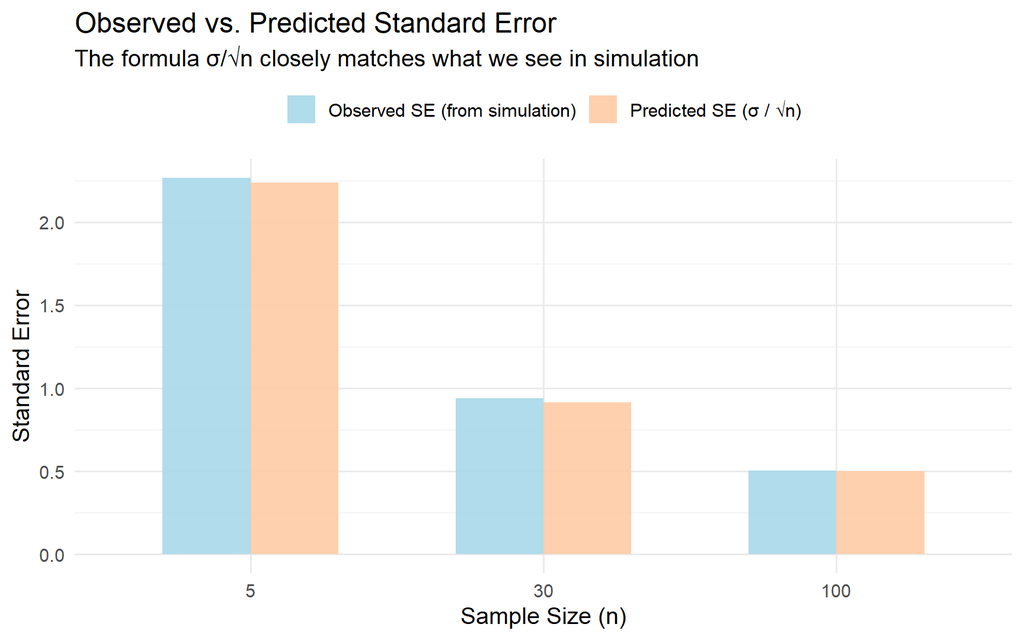

```r
ns <- c(small_n, medium_n, large_n)
observed_se <- c(sd(means_small), sd(means_medium), sd(means_large))
predicted_se <- pop_sd / sqrt(ns)

se_df <- data.frame(
  n            = ns,
  observed_se  = observed_se,
  predicted_se = predicted_se
) %>%
  pivot_longer(cols = c(observed_se, predicted_se),
               names_to = "type", values_to = "se") %>%
  mutate(type = recode(type,
    "observed_se"  = "Observed SE (from simulation)",
    "predicted_se" = "Predicted SE (σ / √n)"
  ))

ggplot(se_df, aes(x = factor(n), y = se, fill = type)) +
  geom_col(position = "dodge", width = 0.6, alpha = 0.9) +
  scale_fill_manual(values = c("#a8d8ea", "#ffcba4")) +
  labs(
    title = "Observed vs. Predicted Standard Error",
    subtitle = "The formula σ/√n closely matches what we see in simulation",
    x = "Sample Size (n)",
    y = "Standard Error",
    fill = NULL
  ) +
  theme_minimal(base_size = 13) +
  theme(legend.position = "top")
```

The bars match almost exactly — this confirms the SE formula is correct and that our simulation behaves as theory predicts.

## Step 6: The Shrinking Spread — All Three Overlaid

One final plot to drive home how sample size controls the spread of the sampling distribution:

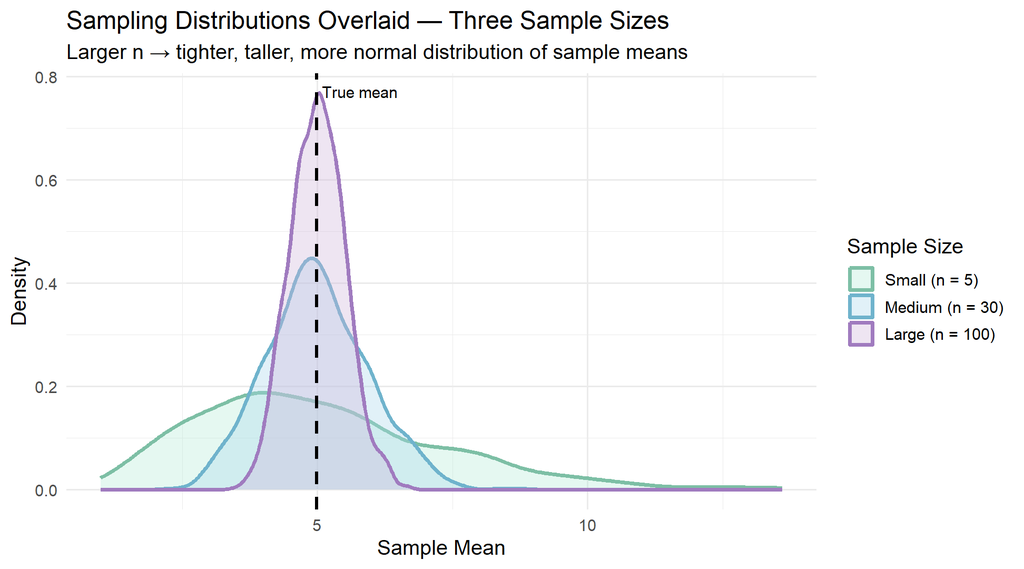

```r
ggplot(sampling_data, aes(x = mean_val, fill = sample_size, color = sample_size)) +
  geom_density(alpha = 0.35, linewidth = 1.1) +
  geom_vline(xintercept = pop_mean, linetype = "dashed", color = "black", linewidth = 1) +
  scale_fill_manual(values  = c("#b5ead7", "#a8d8ea", "#cdb4db")) +
  scale_color_manual(values = c("#7dbfa5", "#6fb3cc", "#a07bbf")) +
  annotate("text", x = pop_mean + 0.8, y = Inf, vjust = 2,
           label = "True mean", size = 3.5) +
  labs(
    title = "Sampling Distributions Overlaid — Three Sample Sizes",
    subtitle = "Larger n → tighter, taller, more normal distribution of sample means",
    x = "Sample Mean",
    y = "Density",
    fill = "Sample Size",
    color = "Sample Size"
  ) +
  theme_minimal(base_size = 13) +
  theme(legend.position = "right")
```

## Key Takeaways

| Concept | What it means |
| --- | --- |
| **Sampling distribution** | Distribution of a statistic (here: the mean) computed from many samples |
| **Central Limit Theorem** | Sample means approach normality as n grows, *regardless* of population shape |
| **Standard Error** | How much sample means vary; equals σ/√n |
| **Larger n → smaller SE** | Bigger samples give more precise, reliable estimates |
| **n ≈ 30 rule of thumb** | Often cited as sufficient for CLT to “kick in” for moderately skewed populations |

The CLT is why so many statistical tests (t-tests, z-tests, confidence intervals) assume normality — not because the *data* is normal, but because the *sample means* are approximately normal when n is large enough.